# Prequestion Performance

- Show All Code
- Hide All Code
- View Source

Bayesian beta-binomial model of the points earned on each prequestion

Author

Jason Geller

Published

October 27, 2026

## What this document does

Participants in the two prequestion conditions answered five prequestions on their topic before reading (Polio or TB). This document describes how much they knew and compares the two conditions. Each prequestion is scored as the points earned out of its maximum (1–4 points) and modelled with a **beta-binomial** model (points out of the question’s maximum, with overdispersion), with random intercepts for participants and questions. Condition varies between participants and between questions (each condition answered its own five questions), so no random slopes are possible.

The comparison TB − Polio is summarized by the posterior mean, 95% credible interval and probability of direction (pd) on the response scale (the proportion of a question’s points), averaged over the sample. It is **described, not tested**: each condition answered its own five questions, so condition is confounded with the set of questions, and no comparison can separate prior knowledge from question difficulty. (A Savage–Dickey Bayes factor would depend on how the question random effects enter the comparison: the response-scale contrast, the link-scale contrast averaged over the sample, and the population-level coefficient disagree.) Shared code (priors, fitting, Bayes factors) is in `R/bayes_helpers.R`; the fit is cached in `analysis/brms_cache/`.

## Setup

```r
library(here)
fit_settings <- list(chains = 4, iter = 11000, warmup = 1000, adapt_delta = 0.95, refit = FALSE)
if (exists("params")) {
  fit_settings <- modifyList(fit_settings, params[intersect(names(params), names(fit_settings))])
}
source(here("R", "setup.R"))
source(here("R", "data.R"))
source(here("R", "bayes_helpers.R"))
```

## Descriptives

```r
# Participant-level scores (grade_prequestions.R), analysed participants
preq_perf <- read_csv(here("data", "derived", "preq_scored_participants.csv"), show_col_types = FALSE) |>
  filter(et_id %in% levels(dat$participant)) |>
  transmute(participant = et_id, condition = recode(et_group, Po = "Polio"),
            pre = points / max_points, attempted = n_answered / n_questions)
preq_perf |>
  group_by(condition) |>
  summarise(n = n(), mean_score = mean(pre), sd_score = sd(pre), attempted = mean(attempted)) |>
  kable(digits = 3, caption = "Prequestion scores (proportion of the points) and proportion of prequestions attempted")
```

Prequestion scores (proportion of the points) and proportion of prequestions attempted

| condition | n | mean_score | sd_score | attempted |
| --- | --- | --- | --- | --- |
| Polio | 45 | 0.041 | 0.052 | 0.431 |
| TB | 46 | 0.105 | 0.109 | 0.396 |

## Model

```r
preq_items <- read_csv(here("data", "derived", "preq_scored_items.csv"), show_col_types = FALSE) |>
  filter(et_id %in% levels(dat$participant)) |>
  transmute(participant = factor(et_id),
            condition = factor(recode(et_group, Po = "Polio"), levels = c("TB", "Polio")),
            question = factor(questnum), points, max_points)
contrasts(preq_items$condition) <- contr.equalprior_pairs

m_preq <- fit_betabin("condition", "bayes_preq_betabin", preq_items,
                      re = "(1 | participant) + (1 | question)", cor = FALSE)
```

```r
diag_tab <- diag_model(m_preq, "prequestions")
diag_tab
```

| model | divergences | max_rhat | min_ess_bulk |
| --- | --- | --- | --- |
| prequestions | 0 | 1.000496 | 8000.128 |

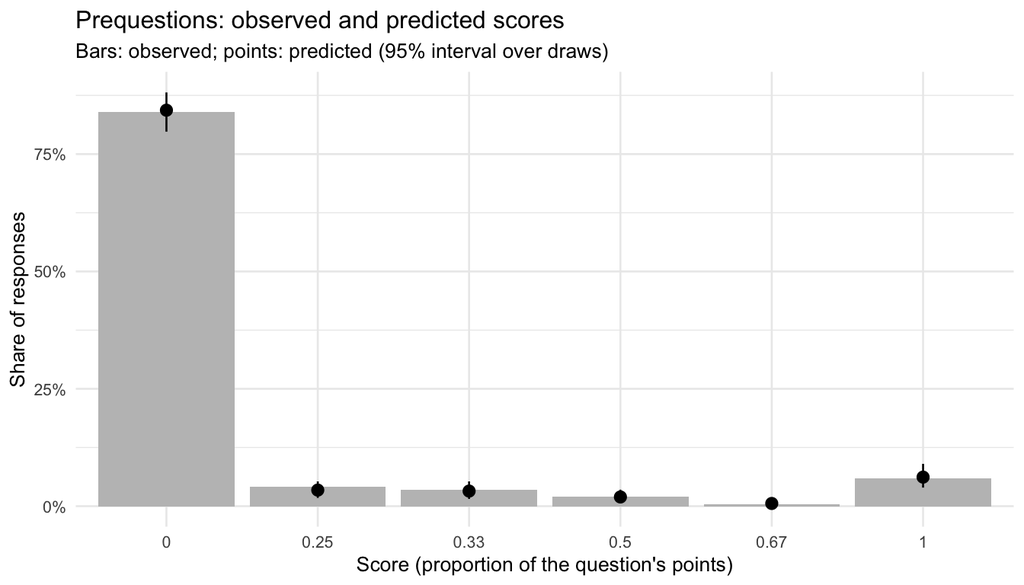

Figure 1

```r
ppc_scores(m_preq, "Prequestions: observed and predicted scores")
```

## TB − Polio

```r
preq_means <- resp_means(m_preq, "condition", predict = "mu")
preq_diff <- estimate_contrasts(m_preq, contrast = "condition", comparison = "revpairwise",
                                predict = "mu", backend = "marginaleffects",
                                estimate = "average", centrality = "mean") |>
  as.data.frame()
preq_means
```

|  | condition | ROPE_CI | Mean | CI_low | CI_high | pd | ROPE_low | ROPE_high | ROPE_Percentage |
| --- | --- | --- | --- | --- | --- | --- | --- | --- | --- |
| 1 | TB | 0.95 | 0.10562811 | 0.07913140 | 0.1358073 | 1 | -0.1 | 0.1 | 0.3548684 |
| 2 | Polio | 0.95 | 0.08600899 | 0.05832661 | 0.1154383 | 1 | -0.1 | 0.1 | 0.8498158 |

```r
preq_diff
```

|  | Level1 | Level2 | ROPE_CI | Mean | CI_low | CI_high | pd | ROPE_low | ROPE_high | ROPE_Percentage |
| --- | --- | --- | --- | --- | --- | --- | --- | --- | --- | --- |
| 1 | TB | Polio | 0.95 | 0.01961912 | -0.0196041 | 0.05974202 | 0.82965 | -0.1 | 0.1 | 1 |

## Prior sensitivity

```r
sens_tab <- sens_table(list(prequestions = m_preq))
sens_tab
```

| variable | prior | likelihood | diagnosis | model |
| --- | --- | --- | --- | --- |
| b_Intercept | 0.10490756 | 0.1308639 | potential prior-likelihood conflict | prequestions |
| b_condition1 | 0.07315144 | 0.0490894 | potential strong prior / weak likelihood | prequestions |

## Results file

```r
save_results(list(preq_means = preq_means, preq_diff = preq_diff,
                  diag = diag_tab, sens = sens_tab),
             here("analysis", "results_prequestions.rds"))
```